# Unsexed Nestling Analysis

Justin Mann

2023-03-28

```r
library(tidyverse)
library(dplyr)
library(broom) #tidy() to create tibbles from model summaries
library(car) #vif
```

```r
library(cowplot)
library(lme4) #frequentist models
library(sjPlot) #plot_model & tab_model (blue = #377EB8)
library(ggpubr) #ggarrange
library(glmmTMB) #zi & overdispersed models
library(lmerTest) #lmerTest::step
library(ggeffects) #ggpredict
#PACKAGES FOR BAYESIAN MODELS
library(rstanarm) #stan models
library(shinystan) #stan model evaluation
#launch_shinystan_demo()
library(loo) #use loo() to compare fits between bayesian models
library(ggeffects)
library(plotly)
library(MuMIn) #dredge() for unsupervised model selection
library(AICcmodavg) #aictab() for AICc model comparisons
library(DHARMa)
library(DescTools)
library(umap)
library(tsne)
library(ggfortify)#use autoplot() to visualize PCAs
theme_set(theme_classic())
```

## Data

```r
df <- read.csv("CrowNestlingClimate_AllNestlingsCleaned&ClimateJoined.csv", h=TRUE)
df <- df[,-1]
#n=2035 nestlings, 39 variables
```

A column to hold decade bins for plotting

```r
df$Decades <- cut(df$Year, breaks = c(1988,1999,2010,2018), labels = c("89-99","00-10","11-18"))
df <- df %>% relocate(Decades, .before = Year)
```

## Normalize Continuous Data

Subtract each value from the mean (center) and divide it by the standard deviation

```r
#categorical data
unScaled.df <- df[,1:11]

#continuous data
dataToScale.df <- df[,12:40]

#scale continuous data
#?scale()
scaled.mat <- scale(dataToScale.df, center = TRUE, scale = TRUE)

#join unscaled and scaled data
scaled.df <- cbind(unScaled.df,scaled.mat)
```

Summarize the unscaled data

```r
summary(df)
```

```
##   Decades         Year          Name             NestName
##  89-99:751   Min.   :1989   Length:2035        Length:2035
##  00-10:781   1st Qu.:1996   Class :character   Class :character
##  11-18:503   Median :2004   Mode  :character   Mode  :character
##              Mean   :2003
##              3rd Qu.:2010
##              Max.   :2018
##
##       ID               FieldAge        CalcAge       HatchDateJul
##  Length:2035        Min.   :20.00   Min.   :24.00   Min.   : 99.0
##  Class :character   1st Qu.:25.00   1st Qu.:25.30   1st Qu.:109.0
##  Mode  :character   Median :26.00   Median :26.00   Median :114.0
##                     Mean   :26.37   Mean   :26.16   Mean   :115.5
##                     3rd Qu.:28.00   3rd Qu.:26.95   3rd Qu.:119.0
##                     Max.   :31.00   Max.   :29.90   Max.   :164.0
##                     NA's   :159
##  HatchDateJulYear      Date              AllSex               BNT
##  Min.   :1989112   Length:2035        Length:2035        Min.   :15.60
##  1st Qu.:1996117   Class :character   Class :character   1st Qu.:21.40
##  Median :2004109   Mode  :character   Mode  :character   Median :22.50
##  Mean   :2003604                                         Mean   :22.51
##  3rd Qu.:2010126                                         3rd Qu.:23.60
##  Max.   :2018139                                         Max.   :28.80
##
##        BW              BD             TEC             Head
##  Min.   : 0.00   Min.   : 9.20   Min.   :22.30   Min.   :55.90
##  1st Qu.:12.20   1st Qu.:12.30   1st Qu.:33.20   1st Qu.:73.90
##  Median :12.80   Median :12.80   Median :34.80   Median :76.40
##  Mean   :12.84   Mean   :12.81   Mean   :34.74   Mean   :76.25
##  3rd Qu.:13.50   3rd Qu.:13.30   3rd Qu.:36.40   3rd Qu.:78.70
##  Max.   :18.40   Max.   :16.00   Max.   :52.60   Max.   :94.00
##
##        UB             UBS              TBS            Skull
##  Min.   : 4.30   Min.   : 56.33   Min.   :113.7   Min.   :20.60
##  1st Qu.:11.50   1st Qu.:143.50   1st Qu.:206.2   1st Qu.:40.30
##  Median :12.20   Median :156.21   Median :222.3   Median :41.60
##  Mean   :12.22   Mean   :156.89   Mean   :223.2   Mean   :41.52
##  3rd Qu.:13.00   3rd Qu.:170.30   3rd Qu.:239.9   3rd Qu.:42.90
##  Max.   :31.80   Max.   :378.40   Max.   :321.1   Max.   :56.70
##
```

[output cut: 25 more lines]

```
##  Min.   :  1.00   Min.   :  0.0    Min.   : 0.000   Min.   : 0.000
##  1st Qu.: 36.00   1st Qu.: 17.0    1st Qu.: 0.000   1st Qu.: 0.000
##  Median : 67.00   Median : 35.0    Median : 0.000   Median : 2.000
##  Mean   : 71.29   Mean   : 42.5    Mean   : 3.555   Mean   : 7.179
##  3rd Qu.: 96.00   3rd Qu.: 61.0    3rd Qu.: 4.000   3rd Qu.:10.000
##  Max.   :247.00   Max.   :338.0    Max.   :54.000   Max.   :82.000
##
##  CDDSumIncubation   HDDSum1_11   HDDSum12_22    HDDSumIncubation
##  Min.   : 0.000   Min.   :  9   Min.   :  0.0   Min.   : 41.0
##  1st Qu.: 0.000   1st Qu.:127   1st Qu.: 81.0   1st Qu.:320.0
##  Median : 0.000   Median :168   Median :118.0   Median :371.0
##  Mean   : 2.804   Mean   :161   Mean   :118.9   Mean   :377.7
##  3rd Qu.: 2.000   3rd Qu.:199   3rd Qu.:158.0   3rd Qu.:431.0
##  Max.   :93.000   Max.   :280   Max.   :250.0   Max.   :576.0
##
```

Summarize the scaled data

```r
summary(scaled.df)
```

```
##   Decades         Year          Name             NestName
##  89-99:751   Min.   :1989   Length:2035        Length:2035
##  00-10:781   1st Qu.:1996   Class :character   Class :character
##  11-18:503   Median :2004   Mode  :character   Mode  :character
##              Mean   :2003
##              3rd Qu.:2010
##              Max.   :2018
##
##       ID               FieldAge        CalcAge       HatchDateJul
##  Length:2035        Min.   :20.00   Min.   :24.00   Min.   : 99.0
##  Class :character   1st Qu.:25.00   1st Qu.:25.30   1st Qu.:109.0
##  Mode  :character   Median :26.00   Median :26.00   Median :114.0
##                     Mean   :26.37   Mean   :26.16   Mean   :115.5
##                     3rd Qu.:28.00   3rd Qu.:26.95   3rd Qu.:119.0
##                     Max.   :31.00   Max.   :29.90   Max.   :164.0
##                     NA's   :159
##  HatchDateJulYear      Date              AllSex               BNT
##  Min.   :1989112   Length:2035        Length:2035        Min.   :-4.031611
##  1st Qu.:1996117   Class :character   Class :character   1st Qu.:-0.648602
##  Median :2004109   Mode  :character   Mode  :character   Median :-0.006996
##  Mean   :2003604                                         Mean   : 0.000000
##  3rd Qu.:2010126                                         3rd Qu.: 0.634609
##  Max.   :2018139                                         Max.   : 3.667651
##
##        BW                  BD               TEC               Head
##  Min.   :-12.45669   Min.   :-4.4606   Min.   :-5.1473   Min.   :-5.57511
##  1st Qu.: -0.61935   1st Qu.:-0.6314   1st Qu.:-0.6357   1st Qu.:-0.64426
##  Median : -0.03718   Median :-0.0138   Median : 0.0266   Median : 0.04058
##  Mean   :  0.00000   Mean   : 0.0000   Mean   : 0.0000   Mean   : 0.00000
##  3rd Qu.:  0.64201   3rd Qu.: 0.6038   3rd Qu.: 0.6889   3rd Qu.: 0.67064
##  Max.   :  5.39635   Max.   : 3.9389   Max.   : 7.3942   Max.   : 4.86186
##
##        UB                UBS                TBS               Skull
##  Min.   :-5.72092   Min.   :-4.50254   Min.   :-4.30764   Min.   :-9.60047
##  1st Qu.:-0.52257   1st Qu.:-0.59959   1st Qu.:-0.66990   1st Qu.:-0.55819
##  Median :-0.01718   Median :-0.03051   Median :-0.03642   Median : 0.03851
##  Mean   : 0.00000   Mean   : 0.00000   Mean   : 0.00000   Mean   : 0.00000
##  3rd Qu.: 0.56041   3rd Qu.: 0.60035   3rd Qu.: 0.65642   3rd Qu.: 0.63521
##  Max.   :14.13387   Max.   : 9.91782   Max.   : 3.85044   Max.   : 6.96939
##
```

[output cut: 33 more lines]

```
##  Min.   :-0.6046   Min.   :-0.4340   Min.   :-3.0649   Min.   :-2.39145
##  1st Qu.:-0.6046   1st Qu.:-0.4340   1st Qu.:-0.6859   1st Qu.:-0.76212
##  Median :-0.4361   Median :-0.4340   Median : 0.1407   Median :-0.01786
##  Mean   : 0.0000   Mean   : 0.0000   Mean   : 0.0000   Mean   : 0.00000
##  3rd Qu.: 0.2376   3rd Qu.:-0.1244   3rd Qu.: 0.7656   3rd Qu.: 0.78674
##  Max.   : 6.3012   Max.   :13.9602   Max.   : 2.3987   Max.   : 2.63734
##
##  HDDSumIncubation
##  Min.   :-3.68630
##  1st Qu.:-0.63145
##  Median :-0.07303
##  Mean   : 0.00000
##  3rd Qu.: 0.58393
##  Max.   : 2.17158
##
```

```r
#Males Scaled
M.scaled.df <- subset(scaled.df, AllSex=="M")
#Males Unscaled
M.df <- subset(df, AllSex=="M")

#Females Scaled
F.scaled.df <- subset(scaled.df, AllSex=="F")
#Females Unscaled
F.df <- subset(df, AllSex=="F")

#Both sexes scaled
B.scaled.df <- rbind(F.scaled.df,M.scaled.df)
#Both sexes unscaled
B.df <- rbind(F.df,M.df)
```

## Climate PCA

```r
climPCA.ids <- scaled.df %>% select(Year,HatchDateJul)
climPCA.mat <- scaled.df %>% select(MeanMaxTempIncubation,MaxTempMean1_11,MaxTempMean12_22,MeanMinTempIncubation,MinTempMean1_11,MinTempMean12_22,PrecipSumIncubation,PrecipSum1_11,PrecipSum12_22)
```

```r
#all climate variables
climPCA <- prcomp(climPCA.mat)
#max temps only
maxPCA <- prcomp(climPCA.mat[,1:3])
#min temps only
minPCA <- prcomp(climPCA.mat[4:6])
#precip only
precipPCA <- prcomp(climPCA.mat[,7:9])
```

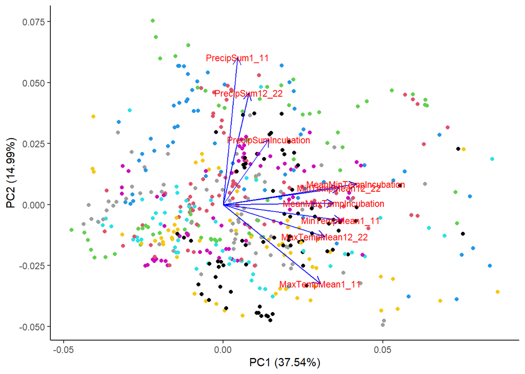

```r
autoplot(climPCA, colour=as.factor(climPCA.ids$Year),
         loadings = TRUE, loadings.colour = 'blue',
         loadings.label = TRUE, loadings.label.size = 3)
```

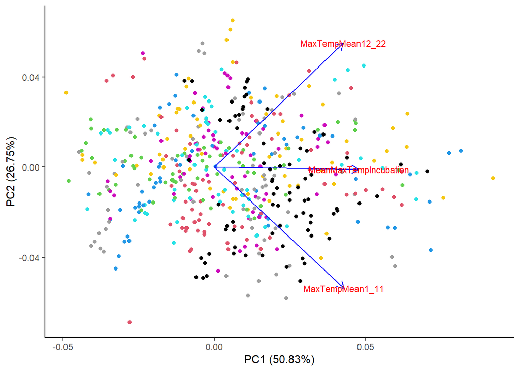

```r
autoplot(maxPCA, colour=as.factor(climPCA.ids$Year),
         loadings = TRUE, loadings.colour = 'blue',
         loadings.label = TRUE, loadings.label.size = 3)
```

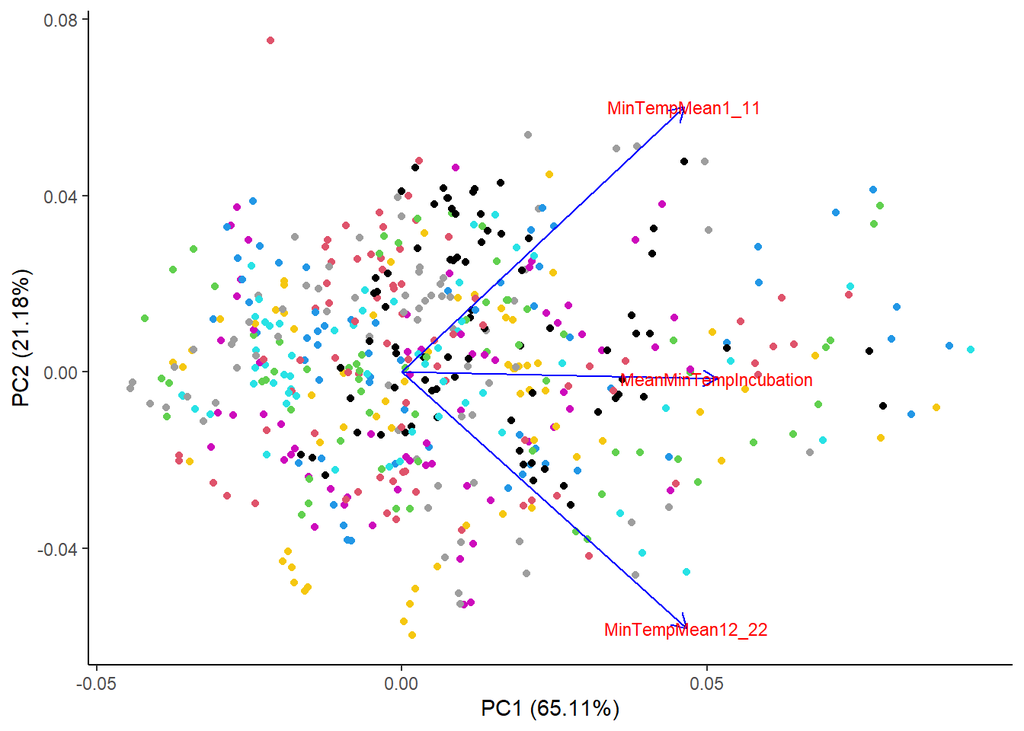

```r
autoplot(minPCA, colour=as.factor(climPCA.ids$Year),
         loadings = TRUE, loadings.colour = 'blue',
         loadings.label = TRUE, loadings.label.size = 3)
```

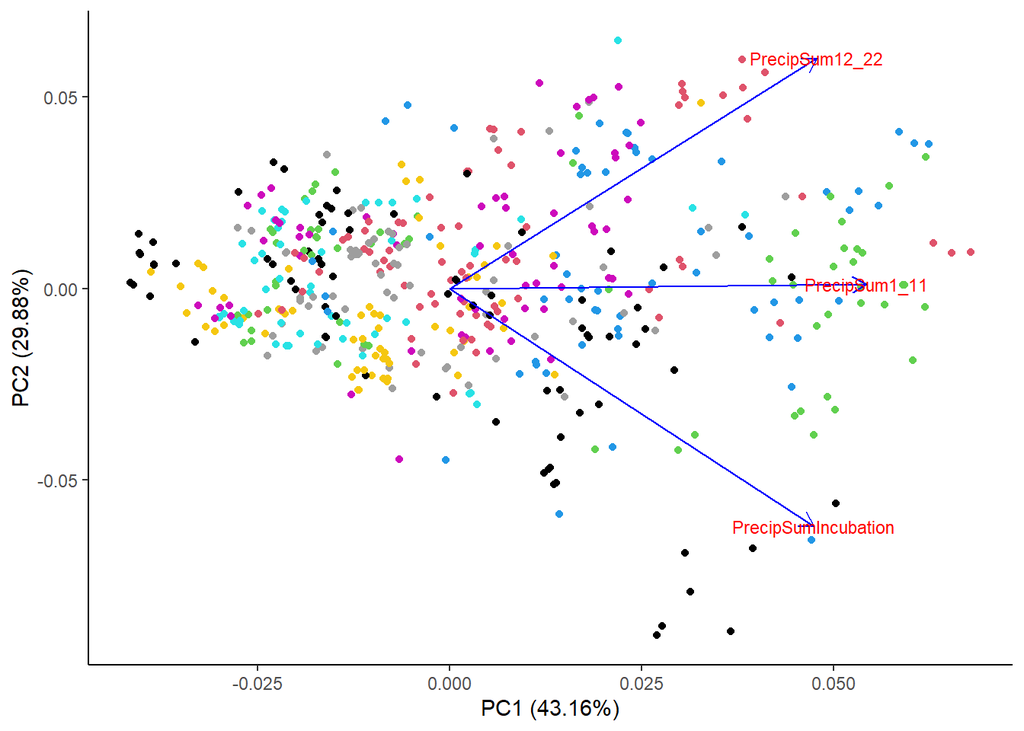

```r
autoplot(precipPCA, colour=as.factor(climPCA.ids$Year),
         loadings = TRUE, loadings.colour = 'blue',
         loadings.label = TRUE, loadings.label.size = 3)
```

## Bill Depth by sex

What is the mean bill depth of males and females?

```r
t.test(B.df$BD[B.df$AllSex=="M"], B.df$BD[B.df$AllSex=="F"])
```

```
##
##  Welch Two Sample t-test
##
## data:  B.df$BD[B.df$AllSex == "M"] and B.df$BD[B.df$AllSex == "F"]
## t = 8.5469, df = 1011.6, p-value < 2.2e-16
## alternative hypothesis: true difference in means is not equal to 0
## 95 percent confidence interval:
##  0.3254400 0.5194129
## sample estimates:
## mean of x mean of y
##  12.97674  12.55431
```

Plot unscaled bill depth distributions for males and females with verticle lines showing the mean values.

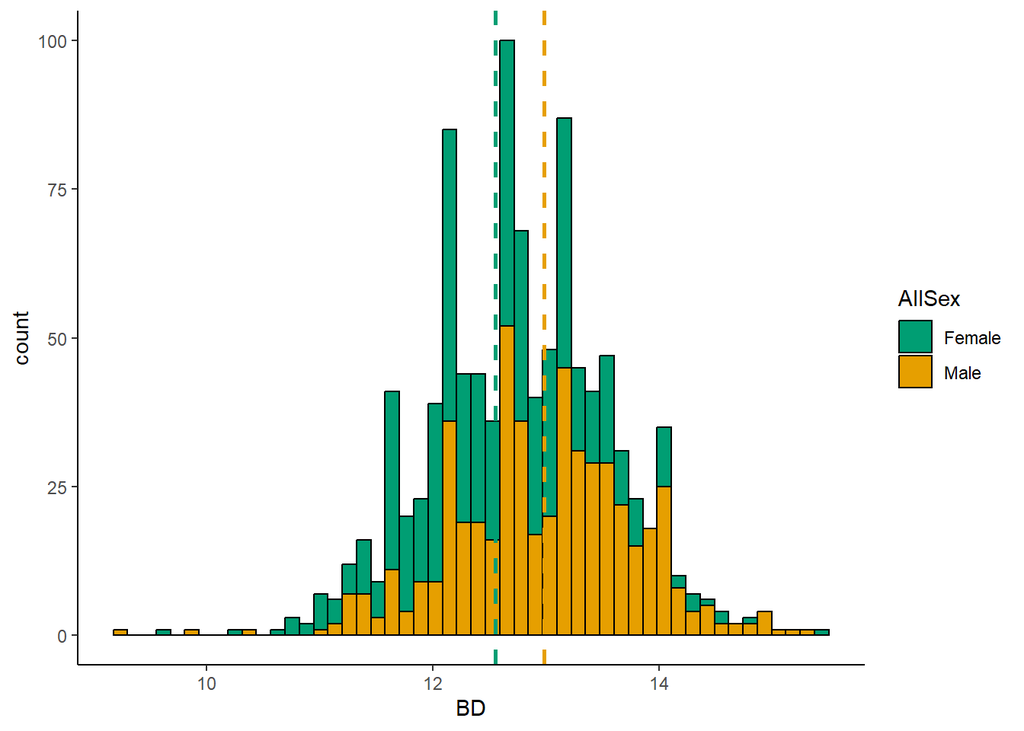

```r
ggplot(data = B.df, aes(x=BD, fill = AllSex))+
  geom_histogram(colour = "black", bins = 50)+
  geom_vline(xintercept = 12.55, color="#009E73", linetype="dashed", size=1)+
  geom_vline(xintercept = 12.98, color="#E69F00", linetype="dashed", size=1)+
  scale_fill_manual(values = c("#009E73","#E69F00"), labels = c("Female","Male"))
```

Plot the residuals of a scaled model showing how weight and age explain bill depth.

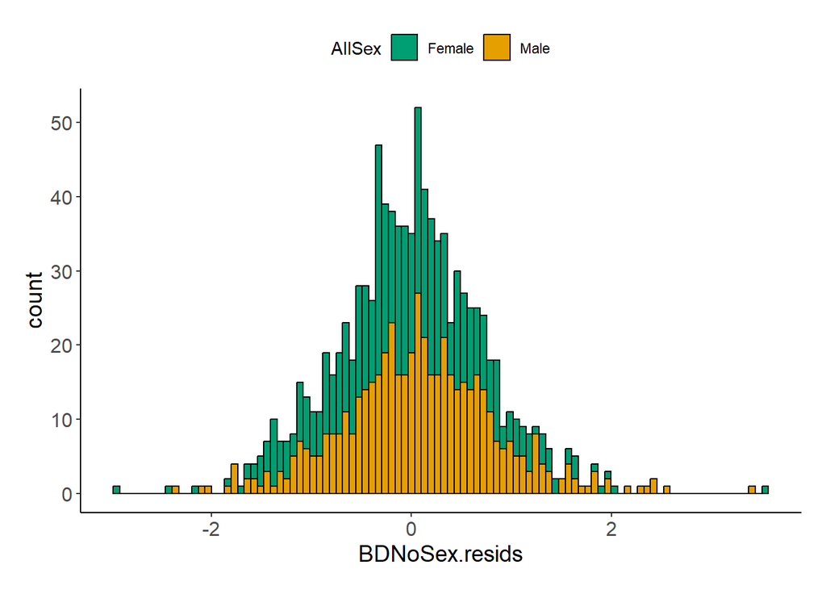

```r
#Scaled BD
BDNoSex.scaled.mdl <- lm(data = B.scaled.df, BD ~ Weight + CalcAge)
BDNoSex.summ <- summary(BDNoSex.scaled.mdl)
B.scaled.df$BDNoSex.resids <- BDNoSex.summ$residuals

ggplot(data = B.scaled.df, aes(x=BDNoSex.resids,fill=AllSex))+
  geom_histogram(colour = "black", bins = 100)+
  scale_fill_manual(values = c("#009E73","#E69F00"), labels = c("Female","Male"))+
  theme(plot.title = element_text(size = 22),
          axis.text.x = element_text(size = 12),
          axis.title.x = element_text(size = 14),
          axis.text.y = element_text(size = 12),
          axis.title.y = element_text(size = 14),
          legend.position = "top",
          plot.margin = margin(15,15,15,15))
```

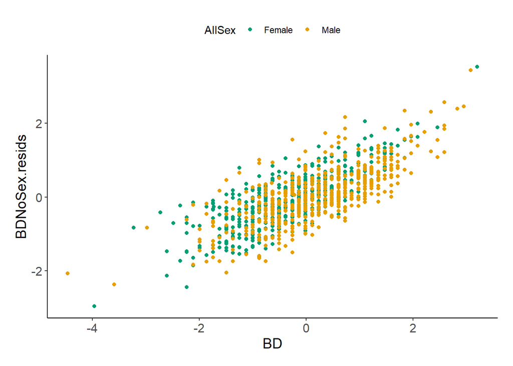

```r
ggplot(data = B.scaled.df, aes(x=BD,y=BDNoSex.resids,color=AllSex))+
  geom_point()+
  scale_color_manual(values = c("#009E73","#E69F00"), labels = c("Female","Male"))+
  theme(plot.title = element_text(size = 22),
          axis.text.x = element_text(size = 12),
          axis.title.x = element_text(size = 14),
          axis.text.y = element_text(size = 12),
          axis.title.y = element_text(size = 14),
          legend.position = "top",
          plot.margin = margin(15,15,15,15))
```

```r
mean(B.scaled.df$BDNoSex.resids[B.scaled.df$AllSex=="M"])
```

```
## [1] 0.07694654
```

```r
mean(B.scaled.df$BDNoSex.resids[B.scaled.df$AllSex=="F"])
```

```
## [1] -0.07909674
```

```r
t.test(B.scaled.df$BDNoSex.resids[B.scaled.df$AllSex=="M"],B.scaled.df$BDNoSex.resids[B.scaled.df$AllSex=="F"])
```

```
##
##  Welch Two Sample t-test
##
## data:  B.scaled.df$BDNoSex.resids[B.scaled.df$AllSex == "M"] and B.scaled.df$BDNoSex.resids[B.scaled.df$AllSex == "F"]
## t = 3.2774, df = 1013.8, p-value = 0.001083
## alternative hypothesis: true difference in means is not equal to 0
## 95 percent confidence interval:
##  0.06261479 0.24947176
## sample estimates:
##   mean of x   mean of y
##  0.07694654 -0.07909674
```

```r
TruncBD.df <- B.scaled.df %>% filter(between(BD,-1,1))
t.test(TruncBD.df$BDNoSex.resids[TruncBD.df$AllSex=="M"],TruncBD.df$BDNoSex.resids[TruncBD.df$AllSex=="F"])
```

```
##
##  Welch Two Sample t-test
##
## data:  TruncBD.df$BDNoSex.resids[TruncBD.df$AllSex == "M"] and TruncBD.df$BDNoSex.resids[TruncBD.df$AllSex == "F"]
## t = -1.5997, df = 674.07, p-value = 0.1101
## alternative hypothesis: true difference in means is not equal to 0
## 95 percent confidence interval:
##  -0.15273013  0.01559229
## sample estimates:
##   mean of x   mean of y
## -0.02304438  0.04552454
```

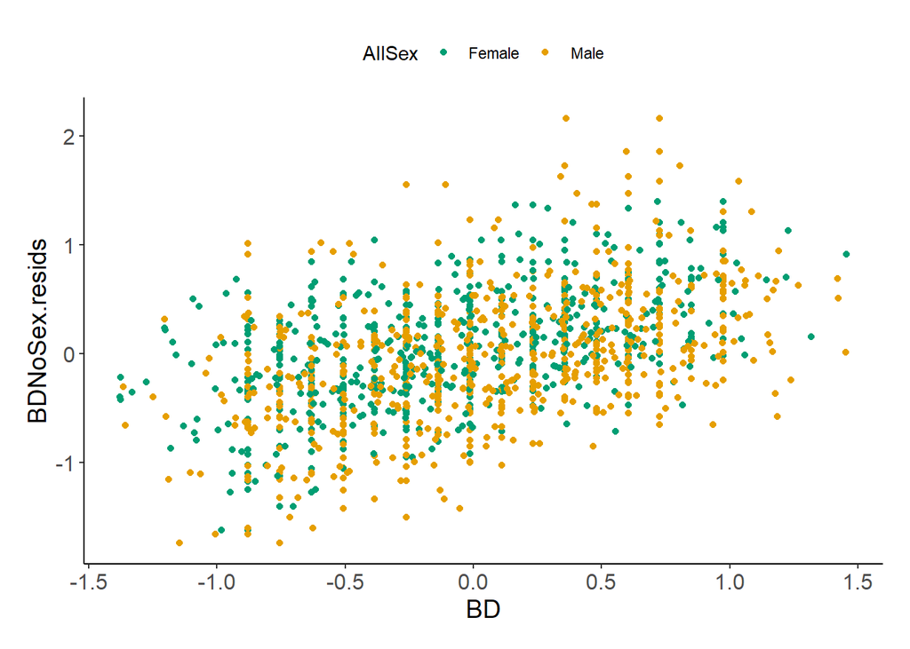

```r
ggplot(data = TruncBD.df, aes(x=BD,y=BDNoSex.resids,color=AllSex))+
  geom_point()+
  geom_jitter(width = 0.5)+
  scale_color_manual(values = c("#009E73","#E69F00"), labels = c("Female","Male"))+
  theme(plot.title = element_text(size = 22),
          axis.text.x = element_text(size = 12),
          axis.title.x = element_text(size = 14),
          axis.text.y = element_text(size = 12),
          axis.title.y = element_text(size = 14),
          legend.position = "top",
          plot.margin = margin(15,15,15,15))
```

## Tarsus comparisons by sex

```r
t.test(B.df$Tarsus[B.df$AllSex=="M"], B.df$Tarsus[B.df$AllSex=="F"])
```

```
##
##  Welch Two Sample t-test
##
## data:  B.df$Tarsus[B.df$AllSex == "M"] and B.df$Tarsus[B.df$AllSex == "F"]
## t = 10.597, df = 1001.9, p-value < 2.2e-16
## alternative hypothesis: true difference in means is not equal to 0
## 95 percent confidence interval:
##  1.543270 2.244746
## sample estimates:
## mean of x mean of y
##  59.90016  58.00615
```

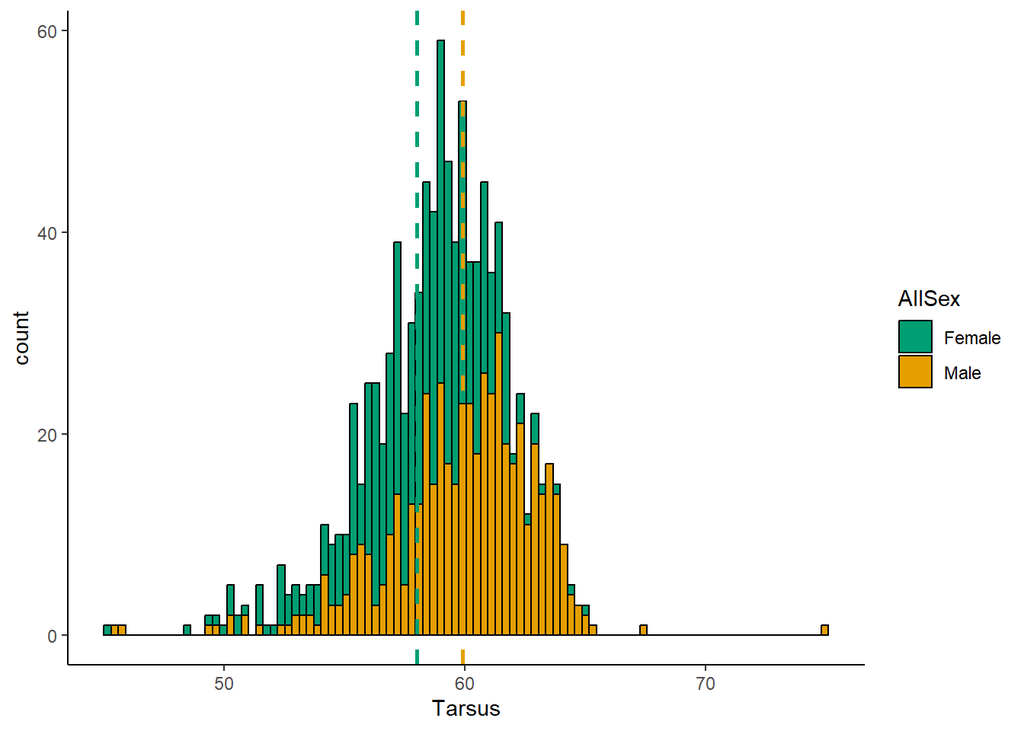

```r
ggplot(data = B.df, aes(x=Tarsus, fill = AllSex))+
  geom_histogram(colour = "black", bins = 100)+
  geom_vline(xintercept = 58.006, color="#009E73", linetype="dashed", size=1)+
  geom_vline(xintercept = 59.9, color="#E69F00", linetype="dashed", size=1)+
  scale_fill_manual(values = c("#009E73","#E69F00"), labels = c("Female","Male"))
```

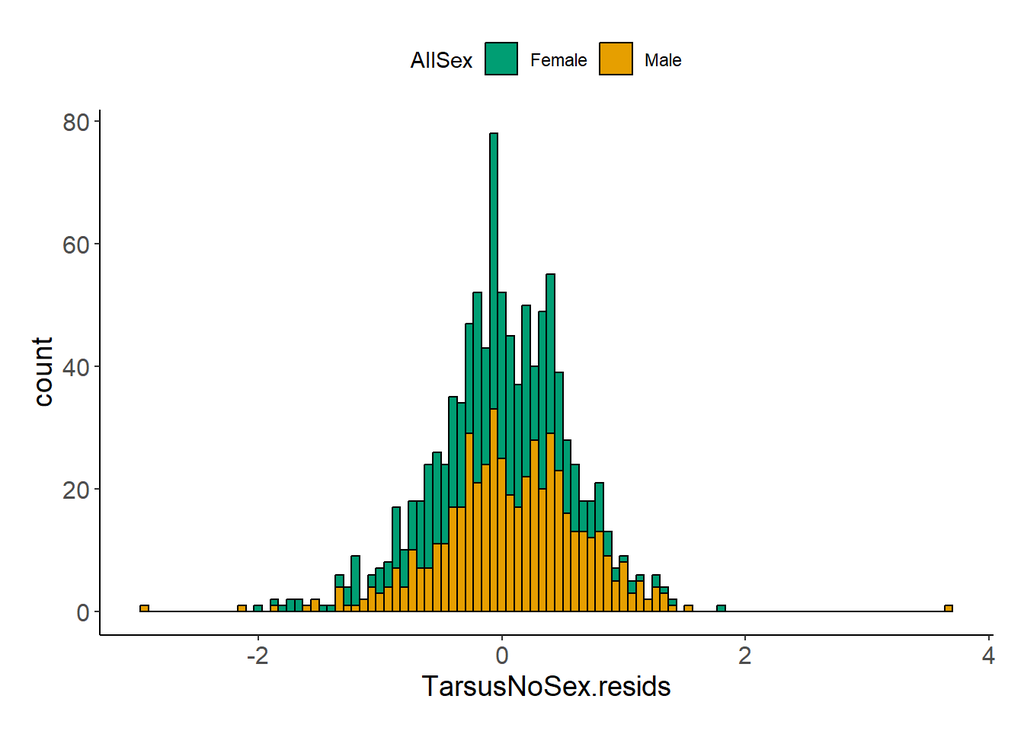

```r
#Scaled tarsus
TarsusNoSex.scaled.mdl <- lm(data = B.scaled.df, Tarsus ~ Weight + CalcAge)
TarsusNoSex.summ <- summary(TarsusNoSex.scaled.mdl)
B.scaled.df$TarsusNoSex.resids <- TarsusNoSex.summ$residuals

ggplot(data = B.scaled.df, aes(x=TarsusNoSex.resids,fill=AllSex))+
  geom_histogram(colour = "black", bins = 100)+
  scale_fill_manual(values = c("#009E73","#E69F00"), labels = c("Female","Male"))+
  theme(plot.title = element_text(size = 22),
          axis.text.x = element_text(size = 12),
          axis.title.x = element_text(size = 14),
          axis.text.y = element_text(size = 12),
          axis.title.y = element_text(size = 14),
          legend.position = "top",
          plot.margin = margin(15,15,15,15))
```

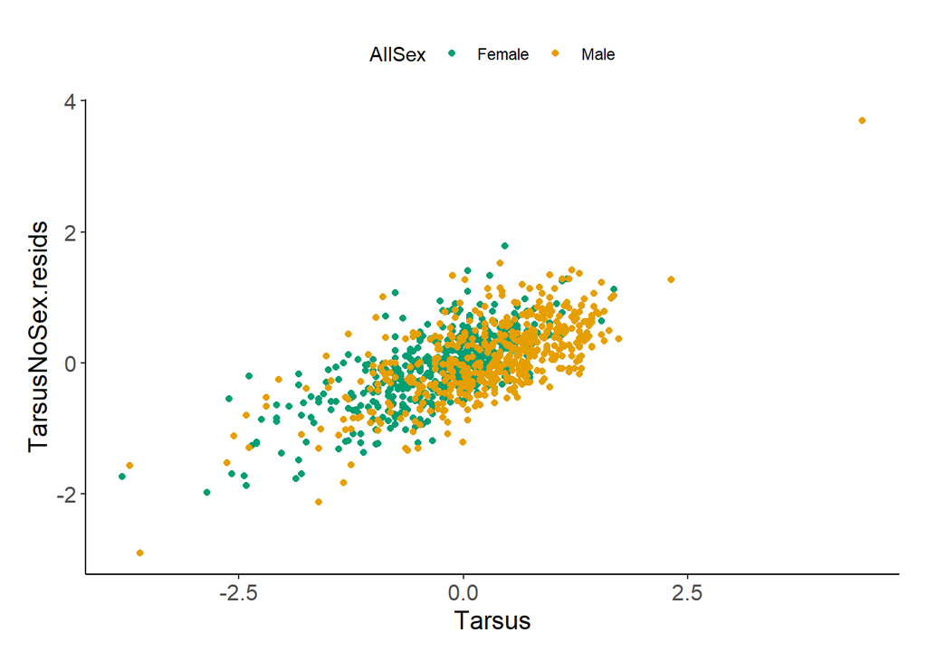

```r
ggplot(data = B.scaled.df, aes(x=Tarsus,y=TarsusNoSex.resids,color=AllSex))+
  geom_point()+
  scale_color_manual(values = c("#009E73","#E69F00"), labels = c("Female","Male"))+
  theme(plot.title = element_text(size = 22),
          axis.text.x = element_text(size = 12),
          axis.title.x = element_text(size = 14),
          axis.text.y = element_text(size = 12),
          axis.title.y = element_text(size = 14),
          legend.position = "top",
          plot.margin = margin(15,15,15,15))
```

```r
t.test(B.scaled.df$TarsusNoSex.resids[B.scaled.df$AllSex=="M"],B.scaled.df$TarsusNoSex.resids[B.scaled.df$AllSex=="F"])
```

```
##
##  Welch Two Sample t-test
##
## data:  B.scaled.df$TarsusNoSex.resids[B.scaled.df$AllSex == "M"] and B.scaled.df$TarsusNoSex.resids[B.scaled.df$AllSex == "F"]
## t = 4.0873, df = 1008.7, p-value = 4.711e-05
## alternative hypothesis: true difference in means is not equal to 0
## 95 percent confidence interval:
##  0.07596129 0.21625532
## sample estimates:
##  mean of x  mean of y
##  0.0720475 -0.0740608
```

## Bill Depth Models

Bayesian Bill Depth GDD Incubation model

```r
BDIncub.bmdl <- stan_glm(BD ~ GDDSumIncubation * PrecipSumIncubation + Weight + CalcAge,
                              data = scaled.df,
                              family = gaussian(),
                              algorithm = "sampling",
                              prior = student_t(df = 7, 0, 5),
                              prior_intercept = student_t(df = 7, 0, 5),
                              cores = 2, seed = 666)
print(summary(BDIncub.bmdl), digits = 3)
```

```
##
## Model Info:
##  function:     stan_glm
##  family:       gaussian [identity]
##  formula:      BD ~ GDDSumIncubation * PrecipSumIncubation + Weight + CalcAge
##  algorithm:    sampling
##  sample:       4000 (posterior sample size)
##  priors:       see help('prior_summary')
##  observations: 2035
##  predictors:   6
##
## Estimates:
##                                        mean   sd     10%    50%    90%
## (Intercept)                          -4.052  0.429 -4.601 -4.048 -3.511
## GDDSumIncubation                      0.061  0.017  0.039  0.061  0.083
## PrecipSumIncubation                   0.024  0.018  0.001  0.023  0.046
## Weight                                0.568  0.018  0.545  0.568  0.591
## CalcAge                               0.155  0.016  0.134  0.155  0.176
## GDDSumIncubation:PrecipSumIncubation  0.038  0.019  0.013  0.038  0.062
## sigma                                 0.764  0.012  0.748  0.764  0.780
##
## Fit Diagnostics:
##            mean   sd     10%    50%    90%
## mean_PPD  0.000  0.024 -0.030  0.000  0.031
##
## The mean_ppd is the sample average posterior predictive distribution of the outcome variable (for details see help('summary.stanreg')).
##
## MCMC diagnostics
##                                      mcse  Rhat  n_eff
## (Intercept)                          0.006 0.999 5318
## GDDSumIncubation                     0.000 0.999 5879
## PrecipSumIncubation                  0.000 0.999 5431
## Weight                               0.000 1.000 4633
## CalcAge                              0.000 0.999 5382
## GDDSumIncubation:PrecipSumIncubation 0.000 0.999 4896
## sigma                                0.000 1.001 2720
## mean_PPD                             0.000 1.000 3587
## log-posterior                        0.045 1.000 1709
##
## For each parameter, mcse is Monte Carlo standard error, n_eff is a crude measure of effective sample size, and Rhat is the potential scale reduction factor on split chains (at convergence Rhat=1).
```

```r
#launch_shinystan(BDTime1.bmdl)
```

```r
BDGDDIncub.plot <- plot(BDIncub.bmdl, pars = c("GDDSumIncubation","PrecipSumIncubation","Weight","CalcAge","GDDSumIncubation:PrecipSumIncubation"))
#BDGDDIncub.plot
```

A Frequentist Bill Depth GDD Time 1 model to compare with the Bayesian version

```r
BDTime1.scaled.mdl <- lm(data = scaled.df, BD ~ GDDSum1_11 * PrecipSum1_11 + Weight + CalcAge)
summary(BDTime1.scaled.mdl)
```

```
##
## Call:
## lm(formula = BD ~ GDDSum1_11 * PrecipSum1_11 + Weight + CalcAge,
##     data = scaled.df)
##
## Residuals:
##     Min      1Q  Median      3Q     Max
## -3.1210 -0.4715 -0.0163  0.4530  4.0108
##
## Coefficients:
##                           Estimate Std. Error t value Pr(>|t|)
## (Intercept)              -4.028555   0.427565  -9.422  < 2e-16 ***
## GDDSum1_11                0.057054   0.017085   3.340 0.000854 ***
## PrecipSum1_11            -0.004085   0.017113  -0.239 0.811376
## Weight                    0.563018   0.018334  30.709  < 2e-16 ***
## CalcAge                   0.153971   0.016329   9.430  < 2e-16 ***
## GDDSum1_11:PrecipSum1_11 -0.002139   0.015915  -0.134 0.893119
## ---
## Signif. codes:  0 '***' 0.001 '**' 0.01 '*' 0.05 '.' 0.1 ' ' 1
##
## Residual standard error: 0.7644 on 2029 degrees of freedom
## Multiple R-squared:  0.4171, Adjusted R-squared:  0.4157
## F-statistic: 290.4 on 5 and 2029 DF,  p-value: < 2.2e-16
```

Bayesian Bill Depth GDD Time 1 model

```r
BDTime1.bmdl <- stan_glm(BD ~ GDDSum1_11 * PrecipSum1_11 + Weight + CalcAge,
                              data = scaled.df,
                              family = gaussian(),
                              algorithm = "sampling",
                              prior = student_t(df = 7, 0, 5),
                              prior_intercept = student_t(df = 7, 0, 5),
                              cores = 2, seed = 666)
print(summary(BDTime1.bmdl), digits = 3)
```

```
##
## Model Info:
##  function:     stan_glm
##  family:       gaussian [identity]
##  formula:      BD ~ GDDSum1_11 * PrecipSum1_11 + Weight + CalcAge
##  algorithm:    sampling
##  sample:       4000 (posterior sample size)
##  priors:       see help('prior_summary')
##  observations: 2035
##  predictors:   6
##
## Estimates:
##                            mean   sd     10%    50%    90%
## (Intercept)              -4.032  0.427 -4.579 -4.034 -3.489
## GDDSum1_11                0.057  0.017  0.035  0.057  0.079
## PrecipSum1_11            -0.004  0.017 -0.026 -0.004  0.018
## Weight                    0.563  0.018  0.540  0.563  0.587
## CalcAge                   0.154  0.016  0.133  0.154  0.175
## GDDSum1_11:PrecipSum1_11 -0.002  0.016 -0.022 -0.002  0.019
## sigma                     0.765  0.012  0.749  0.764  0.781
##
## Fit Diagnostics:
##            mean   sd     10%    50%    90%
## mean_PPD  0.000  0.024 -0.031  0.000  0.030
##
## The mean_ppd is the sample average posterior predictive distribution of the outcome variable (for details see help('summary.stanreg')).
##
## MCMC diagnostics
##                          mcse  Rhat  n_eff
## (Intercept)              0.006 1.000 5598
## GDDSum1_11               0.000 1.000 6764
## PrecipSum1_11            0.000 1.000 6496
## Weight                   0.000 1.000 4868
## CalcAge                  0.000 1.000 5568
## GDDSum1_11:PrecipSum1_11 0.000 1.000 7352
## sigma                    0.000 1.000 3587
## mean_PPD                 0.000 1.000 3606
## log-posterior            0.043 1.001 1908
##
## For each parameter, mcse is Monte Carlo standard error, n_eff is a crude measure of effective sample size, and Rhat is the potential scale reduction factor on split chains (at convergence Rhat=1).
```

```r
#launch_shinystan(BDTime1.bmdl)
```

```r
BDGDDTime1.plot <- plot(BDTime1.bmdl, pars = c("GDDSum1_11","PrecipSum1_11","Weight","CalcAge","GDDSum1_11:PrecipSum1_11"))
#BDGDDTime1.plot
```

Bayesian Bill Depth GDD Time 2

```r
BDTime2.bmdl <- stan_glm(BD ~ GDDSum12_22 * PrecipSum12_22 + Weight + CalcAge,
                              data = scaled.df,
                              family = gaussian(),
                              algorithm = "sampling",
                              prior = student_t(df = 7, 0, 5),
                              prior_intercept = student_t(df = 7, 0, 5),
                              cores = 2, seed = 666)
print(summary(BDTime2.bmdl), digits = 3)
```

```
##
## Model Info:
##  function:     stan_glm
##  family:       gaussian [identity]
##  formula:      BD ~ GDDSum12_22 * PrecipSum12_22 + Weight + CalcAge
##  algorithm:    sampling
##  sample:       4000 (posterior sample size)
##  priors:       see help('prior_summary')
##  observations: 2035
##  predictors:   6
##
## Estimates:
##                              mean   sd     10%    50%    90%
## (Intercept)                -4.327  0.424 -4.866 -4.344 -3.785
## GDDSum12_22                 0.142  0.017  0.119  0.141  0.164
## PrecipSum12_22             -0.010  0.017 -0.032 -0.010  0.012
## Weight                      0.571  0.018  0.548  0.571  0.595
## CalcAge                     0.166  0.016  0.145  0.166  0.186
## GDDSum12_22:PrecipSum12_22 -0.074  0.015 -0.094 -0.074 -0.055
## sigma                       0.752  0.012  0.737  0.752  0.767
##
## Fit Diagnostics:
##            mean   sd     10%    50%    90%
## mean_PPD  0.000  0.023 -0.030  0.000  0.030
##
## The mean_ppd is the sample average posterior predictive distribution of the outcome variable (for details see help('summary.stanreg')).
##
## MCMC diagnostics
##                            mcse  Rhat  n_eff
## (Intercept)                0.006 1.000 5523
## GDDSum12_22                0.000 1.000 5369
## PrecipSum12_22             0.000 0.999 6437
## Weight                     0.000 1.001 5599
## CalcAge                    0.000 1.000 5553
## GDDSum12_22:PrecipSum12_22 0.000 1.000 6960
## sigma                      0.000 1.001 3398
## mean_PPD                   0.000 1.000 3254
## log-posterior              0.045 1.002 1735
##
## For each parameter, mcse is Monte Carlo standard error, n_eff is a crude measure of effective sample size, and Rhat is the potential scale reduction factor on split chains (at convergence Rhat=1).
```

```r
#launch_shinystan(BDTime1.bmdl)
```

```r
BDGDDTime2.plot <- plot(BDTime2.bmdl, pars = c("GDDSum12_22","PrecipSum12_22","Weight","CalcAge","GDDSum12_22:PrecipSum12_22"))
#BDGDDTime2.plot
```

Arrange the Bill Depth model plots

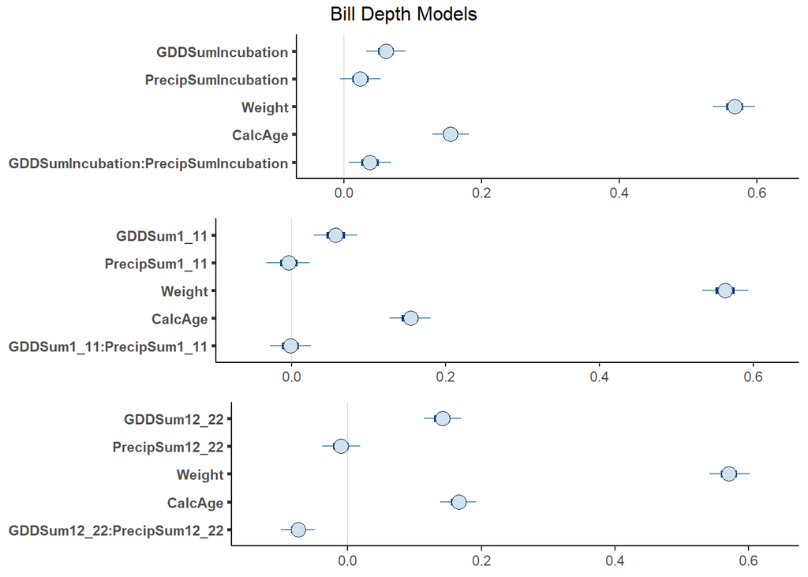

```r
BDModelPlots.wrap <- ggarrange(BDGDDIncub.plot,BDGDDTime1.plot,BDGDDTime2.plot, ncol = 1)
annotate_figure(BDModelPlots.wrap, top = "Bill Depth Models")
```

Plot the interaction between GDD and Precip during incubation

```r
BDGDDIncubInter.plot <- plot_model(BDIncub.bmdl, type = "int", mdrt.values = "quart")

BDGDDIncubInter.plot <- BDGDDIncubInter.plot +
  scale_color_discrete(name="Precip Levels", labels=c("25th Quartile","Median", "75th Quartile"))+
  ylab("Bill Depth")+
  xlab("GDD Incubation")+
  theme(plot.title = element_blank(),
          axis.text.x = element_text(size = 12),
          axis.title.x = element_text(size = 14),
          axis.text.y = element_text(size = 12),
          axis.title.y = element_text(size = 14),
          legend.position = "top",
          plot.margin = margin(15,15,15,15))
#BDGDDIncubInter.plot
```

Plot the interaction between GDD and Precip during Time 2

```r
BDGDDTime2Inter.plot <- plot_model(BDTime2.bmdl, type = "int", mdrt.values = "quart")

BDGDDTime2Inter.plot <- BDGDDTime2Inter.plot +
  scale_color_discrete(name="Precip Levels", labels=c("25th Quartile","Median", "75th Quartile"))+
  ylab("Bill Depth")+
  xlab("GDD Time 2")+
  theme(plot.title = element_blank(),
          axis.text.x = element_text(size = 12),
          axis.title.x = element_text(size = 14),
          axis.text.y = element_text(size = 12),
          axis.title.y = element_text(size = 14),
          legend.position = "top",
          plot.margin = margin(15,15,15,15))
#BDGDDTime2Inter.plot
```

Arrange interaction plots

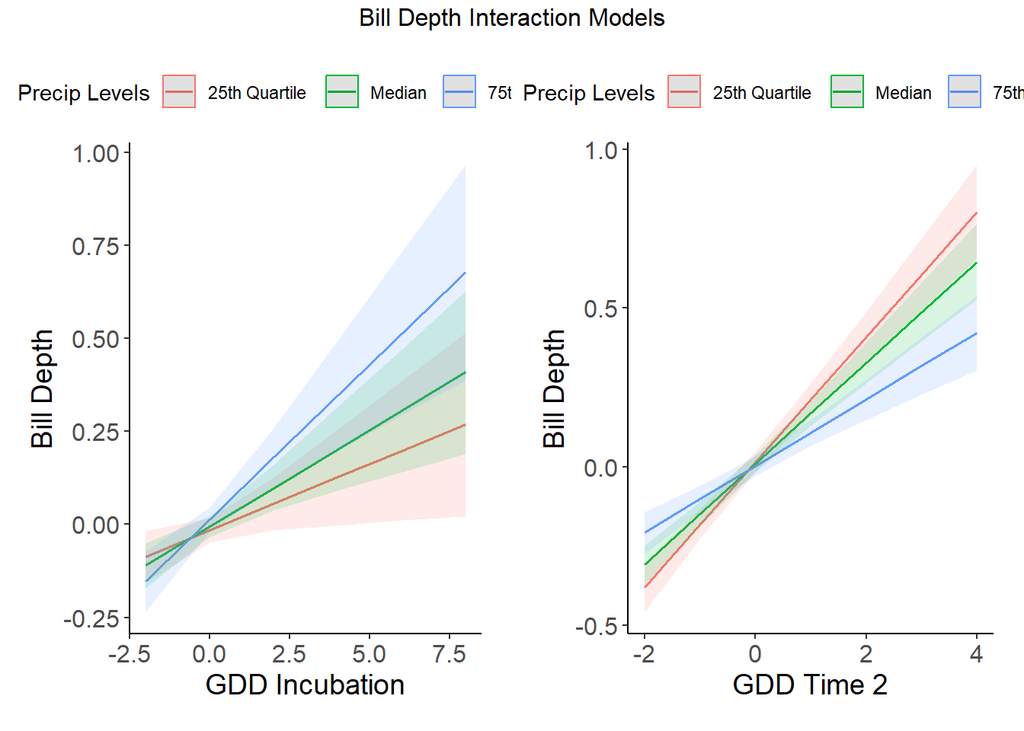

```r
BDInterPlots.wrap <- ggarrange(BDGDDIncubInter.plot,BDGDDTime2Inter.plot, ncol = 2)
annotate_figure(BDInterPlots.wrap, top = "Bill Depth Interaction Models")
```

## Upper Bill Models

Bayesian Upper Bill Incubation model

```r
UBIncub.bmdl <- stan_glm(UB ~ GDDSumIncubation * PrecipSumIncubation + Weight + CalcAge,
                              data = scaled.df,
                              family = gaussian(),
                              algorithm = "sampling",
                              prior = student_t(df = 7, 0, 5),
                              prior_intercept = student_t(df = 7, 0, 5),
                              cores = 2, seed = 666)
print(summary(UBIncub.bmdl), digits = 3)
```

```
##
## Model Info:
##  function:     stan_glm
##  family:       gaussian [identity]
##  formula:      UB ~ GDDSumIncubation * PrecipSumIncubation + Weight + CalcAge
##  algorithm:    sampling
##  sample:       4000 (posterior sample size)
##  priors:       see help('prior_summary')
##  observations: 2035
##  predictors:   6
##
## Estimates:
##                                        mean   sd     10%    50%    90%
## (Intercept)                          -2.768  0.533 -3.443 -2.767 -2.083
## GDDSumIncubation                      0.038  0.022  0.010  0.038  0.067
## PrecipSumIncubation                   0.028  0.021  0.001  0.028  0.056
## Weight                                0.233  0.023  0.204  0.232  0.262
## CalcAge                               0.106  0.020  0.080  0.106  0.132
## GDDSumIncubation:PrecipSumIncubation  0.003  0.024 -0.028  0.002  0.033
## sigma                                 0.957  0.015  0.937  0.957  0.977
##
## Fit Diagnostics:
##            mean   sd     10%    50%    90%
## mean_PPD  0.001  0.030 -0.038  0.000  0.040
##
## The mean_ppd is the sample average posterior predictive distribution of the outcome variable (for details see help('summary.stanreg')).
##
## MCMC diagnostics
##                                      mcse  Rhat  n_eff
## (Intercept)                          0.007 1.000 5753
## GDDSumIncubation                     0.000 0.999 5199
## PrecipSumIncubation                  0.000 0.999 6060
## Weight                               0.000 1.000 5074
## CalcAge                              0.000 1.000 5753
## GDDSumIncubation:PrecipSumIncubation 0.000 1.000 4930
## sigma                                0.000 1.000 3570
## mean_PPD                             0.000 1.000 3858
## log-posterior                        0.047 1.003 1724
##
## For each parameter, mcse is Monte Carlo standard error, n_eff is a crude measure of effective sample size, and Rhat is the potential scale reduction factor on split chains (at convergence Rhat=1).
```

```r
#launch_shinystan(UBTime1.bmdl)
```

```r
UBGDDIncub.plot <- plot(UBIncub.bmdl, pars = c("GDDSumIncubation","PrecipSumIncubation","Weight","CalcAge","GDDSumIncubation:PrecipSumIncubation"))
#UBGDDIncub.plot
```

Bayesian Upper Bill GDD Time 1 model

```r
UBTime1.bmdl <- stan_glm(UB ~ GDDSum1_11 * PrecipSum1_11 + Weight + CalcAge,
                              data = scaled.df,
                              family = gaussian(),
                              algorithm = "sampling",
                              prior = student_t(df = 7, 0, 5),
                              prior_intercept = student_t(df = 7, 0, 5),
                              cores = 2, seed = 666)
print(summary(UBTime1.bmdl), digits = 3)
```

```
##
## Model Info:
##  function:     stan_glm
##  family:       gaussian [identity]
##  formula:      UB ~ GDDSum1_11 * PrecipSum1_11 + Weight + CalcAge
##  algorithm:    sampling
##  sample:       4000 (posterior sample size)
##  priors:       see help('prior_summary')
##  observations: 2035
##  predictors:   6
##
## Estimates:
##                            mean   sd     10%    50%    90%
## (Intercept)              -2.682  0.536 -3.378 -2.679 -2.006
## GDDSum1_11               -0.024  0.021 -0.050 -0.024  0.003
## PrecipSum1_11             0.016  0.022 -0.012  0.016  0.045
## Weight                    0.228  0.023  0.199  0.228  0.257
## CalcAge                   0.103  0.020  0.077  0.102  0.129
## GDDSum1_11:PrecipSum1_11 -0.028  0.019 -0.053 -0.028 -0.003
## sigma                     0.956  0.015  0.937  0.956  0.976
##
## Fit Diagnostics:
##            mean   sd     10%    50%    90%
## mean_PPD  0.000  0.030 -0.039  0.001  0.039
##
## The mean_ppd is the sample average posterior predictive distribution of the outcome variable (for details see help('summary.stanreg')).
##
## MCMC diagnostics
##                          mcse  Rhat  n_eff
## (Intercept)              0.007 1.000 5349
## GDDSum1_11               0.000 1.000 5656
## PrecipSum1_11            0.000 0.999 6311
## Weight                   0.000 1.000 4145
## CalcAge                  0.000 1.000 5333
## GDDSum1_11:PrecipSum1_11 0.000 1.000 6989
## sigma                    0.000 1.000 3846
## mean_PPD                 0.000 1.000 4225
## log-posterior            0.045 1.001 1705
##
## For each parameter, mcse is Monte Carlo standard error, n_eff is a crude measure of effective sample size, and Rhat is the potential scale reduction factor on split chains (at convergence Rhat=1).
```

```r
#launch_shinystan(UBTime1.bmdl)
```

```r
UBGDDTime1.plot <- plot(UBTime1.bmdl, pars = c("GDDSum1_11","PrecipSum1_11","Weight","CalcAge","GDDSum1_11:PrecipSum1_11"))
#UBGDDTime1.plot
```

Bayesian Upper Bill GDD Time 2

```r
UBTime2.bmdl <- stan_glm(UB ~ GDDSum12_22 * PrecipSum12_22 + Weight + CalcAge,
                              data = scaled.df,
                              family = gaussian(),
                              algorithm = "sampling",
                              prior = student_t(df = 7, 0, 5),
                              prior_intercept = student_t(df = 7, 0, 5),
                              cores = 2, seed = 666)
print(summary(UBTime2.bmdl), digits = 3)
```

```
##
## Model Info:
##  function:     stan_glm
##  family:       gaussian [identity]
##  formula:      UB ~ GDDSum12_22 * PrecipSum12_22 + Weight + CalcAge
##  algorithm:    sampling
##  sample:       4000 (posterior sample size)
##  priors:       see help('prior_summary')
##  observations: 2035
##  predictors:   6
##
## Estimates:
##                              mean   sd     10%    50%    90%
## (Intercept)                -2.751  0.540 -3.450 -2.747 -2.054
## GDDSum12_22                 0.039  0.022  0.012  0.039  0.068
## PrecipSum12_22              0.013  0.022 -0.015  0.013  0.040
## Weight                      0.235  0.023  0.205  0.235  0.264
## CalcAge                     0.105  0.021  0.078  0.105  0.131
## GDDSum12_22:PrecipSum12_22  0.052  0.020  0.027  0.052  0.077
## sigma                       0.955  0.015  0.936  0.955  0.975
##
## Fit Diagnostics:
##            mean   sd     10%    50%    90%
## mean_PPD  0.001  0.030 -0.038  0.000  0.039
##
## The mean_ppd is the sample average posterior predictive distribution of the outcome variable (for details see help('summary.stanreg')).
##
## MCMC diagnostics
##                            mcse  Rhat  n_eff
## (Intercept)                0.008 1.001 4065
## GDDSum12_22                0.000 0.999 5540
## PrecipSum12_22             0.000 0.999 4838
## Weight                     0.000 1.000 4441
## CalcAge                    0.000 1.001 4094
## GDDSum12_22:PrecipSum12_22 0.000 1.000 4958
## sigma                      0.000 1.000 3532
## mean_PPD                   0.000 1.000 3626
## log-posterior              0.045 1.002 1829
##
## For each parameter, mcse is Monte Carlo standard error, n_eff is a crude measure of effective sample size, and Rhat is the potential scale reduction factor on split chains (at convergence Rhat=1).
```

```r
#launch_shinystan(UBTime1.bmdl)
```

```r
UBGDDTime2.plot <- plot(UBTime2.bmdl, pars = c("GDDSum12_22","PrecipSum12_22","Weight","CalcAge","GDDSum12_22:PrecipSum12_22"))
#UBGDDTime2.plot
```

Arrange the Upper Bill model plots

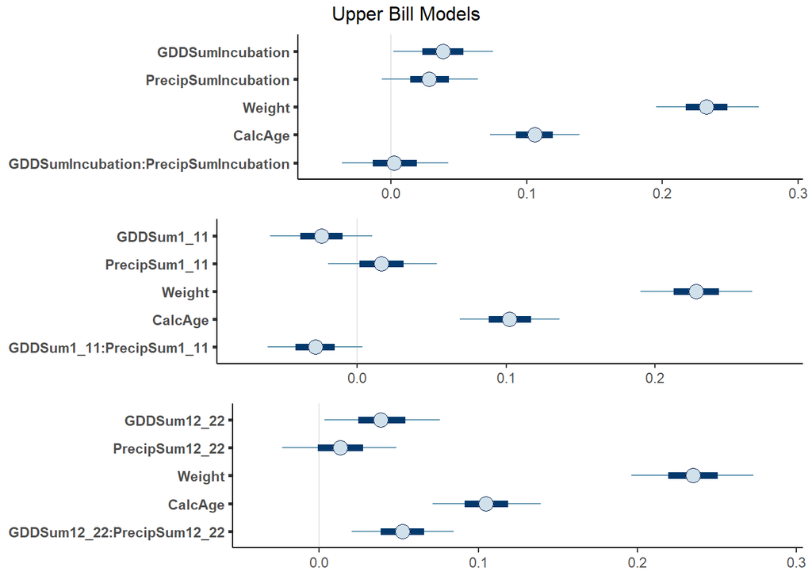

```r
UBModelPlots.wrap <- ggarrange(UBGDDIncub.plot,UBGDDTime1.plot,UBGDDTime2.plot, ncol = 1)
annotate_figure(UBModelPlots.wrap, top = "Upper Bill Models")
```

## Upper Bill Surface Area Models

Bayesian Upper Bill Surface Area Incubation model

```r
UBSIncub.bmdl <- stan_glm(UBS ~ GDDSumIncubation * PrecipSumIncubation + Weight + CalcAge,
                              data = scaled.df,
                              family = gaussian(),
                              algorithm = "sampling",
                              prior = student_t(df = 7, 0, 5),
                              prior_intercept = student_t(df = 7, 0, 5),
                              cores = 2, seed = 666)
print(summary(UBSIncub.bmdl), digits = 3)
```

```
##
## Model Info:
##  function:     stan_glm
##  family:       gaussian [identity]
##  formula:      UBS ~ GDDSumIncubation * PrecipSumIncubation + Weight + CalcAge
##  algorithm:    sampling
##  sample:       4000 (posterior sample size)
##  priors:       see help('prior_summary')
##  observations: 2035
##  predictors:   6
##
## Estimates:
##                                        mean   sd     10%    50%    90%
## (Intercept)                          -3.963  0.490 -4.593 -3.967 -3.330
## GDDSumIncubation                      0.059  0.020  0.034  0.059  0.085
## PrecipSumIncubation                   0.031  0.019  0.006  0.031  0.055
## Weight                                0.433  0.021  0.407  0.434  0.460
## CalcAge                               0.151  0.019  0.127  0.152  0.176
## GDDSumIncubation:PrecipSumIncubation  0.018  0.021 -0.010  0.018  0.045
## sigma                                 0.857  0.014  0.840  0.857  0.875
##
## Fit Diagnostics:
##            mean   sd     10%    50%    90%
## mean_PPD  0.000  0.027 -0.035  0.000  0.034
##
## The mean_ppd is the sample average posterior predictive distribution of the outcome variable (for details see help('summary.stanreg')).
##
## MCMC diagnostics
##                                      mcse  Rhat  n_eff
## (Intercept)                          0.006 1.000 6123
## GDDSumIncubation                     0.000 0.999 5634
## PrecipSumIncubation                  0.000 0.999 6417
## Weight                               0.000 1.000 5040
## CalcAge                              0.000 1.000 6127
## GDDSumIncubation:PrecipSumIncubation 0.000 0.999 4958
## sigma                                0.000 1.000 3706
## mean_PPD                             0.000 1.001 3765
## log-posterior                        0.041 1.002 1903
##
## For each parameter, mcse is Monte Carlo standard error, n_eff is a crude measure of effective sample size, and Rhat is the potential scale reduction factor on split chains (at convergence Rhat=1).
```

```r
#launch_shinystan(UBSTime1.bmdl)
```

```r
UBSGDDIncub.plot <- plot(UBSIncub.bmdl, pars = c("GDDSumIncubation","PrecipSumIncubation","Weight","CalcAge","GDDSumIncubation:PrecipSumIncubation"))
#UBSGDDIncub.plot
```

Bayesian Upper Bill Surface Area GDD Time 1 model

```r
UBSTime1.bmdl <- stan_glm(UBS ~ GDDSum1_11 * PrecipSum1_11 + Weight + CalcAge,
                              data = scaled.df,
                              family = gaussian(),
                              algorithm = "sampling",
                              prior = student_t(df = 7, 0, 5),
                              prior_intercept = student_t(df = 7, 0, 5),
                              cores = 2, seed = 666)
print(summary(UBSTime1.bmdl), digits = 3)
```

```
##
## Model Info:
##  function:     stan_glm
##  family:       gaussian [identity]
##  formula:      UBS ~ GDDSum1_11 * PrecipSum1_11 + Weight + CalcAge
##  algorithm:    sampling
##  sample:       4000 (posterior sample size)
##  priors:       see help('prior_summary')
##  observations: 2035
##  predictors:   6
##
## Estimates:
##                            mean   sd     10%    50%    90%
## (Intercept)              -3.899  0.482 -4.529 -3.898 -3.295
## GDDSum1_11                0.006  0.020 -0.020  0.006  0.032
## PrecipSum1_11             0.011  0.020 -0.014  0.011  0.036
## Weight                    0.427  0.021  0.401  0.427  0.454
## CalcAge                   0.149  0.018  0.126  0.149  0.173
## GDDSum1_11:PrecipSum1_11 -0.024  0.018 -0.047 -0.023  0.000
## sigma                     0.860  0.014  0.842  0.860  0.878
##
## Fit Diagnostics:
##            mean   sd     10%    50%    90%
## mean_PPD  0.000  0.026 -0.034  0.000  0.033
##
## The mean_ppd is the sample average posterior predictive distribution of the outcome variable (for details see help('summary.stanreg')).
##
## MCMC diagnostics
##                          mcse  Rhat  n_eff
## (Intercept)              0.007 1.000 5440
## GDDSum1_11               0.000 0.999 6756
## PrecipSum1_11            0.000 0.999 6495
## Weight                   0.000 1.000 5530
## CalcAge                  0.000 1.000 5436
## GDDSum1_11:PrecipSum1_11 0.000 0.999 6327
## sigma                    0.000 1.001 3735
## mean_PPD                 0.000 1.000 3745
## log-posterior            0.042 1.000 1962
##
## For each parameter, mcse is Monte Carlo standard error, n_eff is a crude measure of effective sample size, and Rhat is the potential scale reduction factor on split chains (at convergence Rhat=1).
```

```r
#launch_shinystan(UBSTime1.bmdl)
```

```r
UBSGDDTime1.plot <- plot(UBSTime1.bmdl, pars = c("GDDSum1_11","PrecipSum1_11","Weight","CalcAge","GDDSum1_11:PrecipSum1_11"))
#UBSGDDTime1.plot
```

Bayesian Upper Bill Surface Area GDD Time 2

```r
UBSTime2.bmdl <- stan_glm(UBS ~ GDDSum12_22 * PrecipSum12_22 + Weight + CalcAge,
                              data = scaled.df,
                              family = gaussian(),
                              algorithm = "sampling",
                              prior = student_t(df = 7, 0, 5),
                              prior_intercept = student_t(df = 7, 0, 5),
                              cores = 2, seed = 666)
print(summary(UBSTime2.bmdl), digits = 3)
```

```
##
## Model Info:
##  function:     stan_glm
##  family:       gaussian [identity]
##  formula:      UBS ~ GDDSum12_22 * PrecipSum12_22 + Weight + CalcAge
##  algorithm:    sampling
##  sample:       4000 (posterior sample size)
##  priors:       see help('prior_summary')
##  observations: 2035
##  predictors:   6
##
## Estimates:
##                              mean   sd     10%    50%    90%
## (Intercept)                -4.076  0.488 -4.692 -4.081 -3.443
## GDDSum12_22                 0.091  0.019  0.067  0.092  0.116
## PrecipSum12_22              0.005  0.019 -0.019  0.005  0.030
## Weight                      0.437  0.020  0.411  0.437  0.462
## CalcAge                     0.156  0.019  0.132  0.156  0.179
## GDDSum12_22:PrecipSum12_22  0.008  0.018 -0.015  0.008  0.030
## sigma                       0.855  0.013  0.839  0.855  0.872
##
## Fit Diagnostics:
##            mean   sd     10%    50%    90%
## mean_PPD  0.000  0.027 -0.034  0.000  0.034
##
## The mean_ppd is the sample average posterior predictive distribution of the outcome variable (for details see help('summary.stanreg')).
##
## MCMC diagnostics
##                            mcse  Rhat  n_eff
## (Intercept)                0.007 1.000 5383
## GDDSum12_22                0.000 0.999 5312
## PrecipSum12_22             0.000 1.000 5935
## Weight                     0.000 1.001 4701
## CalcAge                    0.000 1.000 5360
## GDDSum12_22:PrecipSum12_22 0.000 0.999 5461
## sigma                      0.000 1.001 3418
## mean_PPD                   0.000 1.002 3655
## log-posterior              0.042 1.004 1940
##
## For each parameter, mcse is Monte Carlo standard error, n_eff is a crude measure of effective sample size, and Rhat is the potential scale reduction factor on split chains (at convergence Rhat=1).
```

```r
#launch_shinystan(UBSTime1.bmdl)
```

```r
UBSGDDTime2.plot <- plot(UBSTime2.bmdl, pars = c("GDDSum12_22","PrecipSum12_22","Weight","CalcAge","GDDSum12_22:PrecipSum12_22"))
#UBSGDDTime2.plot
```

Arrange the Upper Bill Surface Area model plots

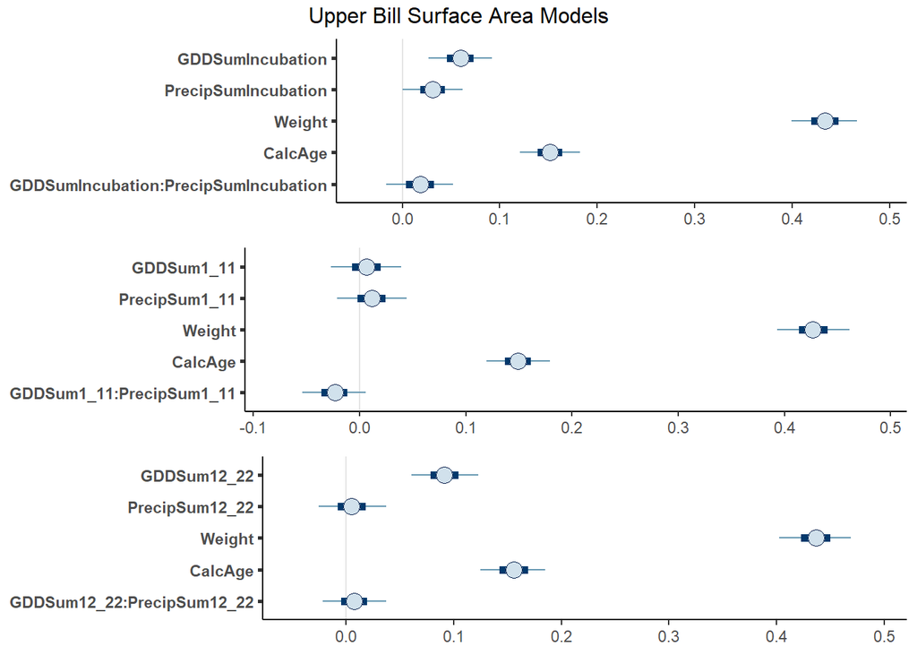

```r
UBSModelPlots.wrap <- ggarrange(UBSGDDIncub.plot,UBSGDDTime1.plot,UBSGDDTime2.plot, ncol = 1)
annotate_figure(UBSModelPlots.wrap, top = "Upper Bill Surface Area Models")
```

## Tarsus Models

Bayesian Tarsus Incubation model

```r
TarsusIncub.bmdl <- stan_glm(Tarsus ~ GDDSumIncubation * PrecipSumIncubation + Weight + CalcAge,
                              data = scaled.df,
                              family = gaussian(),
                              algorithm = "sampling",
                              prior = student_t(df = 7, 0, 5),
                              prior_intercept = student_t(df = 7, 0, 5),
                              cores = 2, seed = 666)
print(summary(TarsusIncub.bmdl), digits = 3)
```

```
##
## Model Info:
##  function:     stan_glm
##  family:       gaussian [identity]
##  formula:      Tarsus ~ GDDSumIncubation * PrecipSumIncubation + Weight + CalcAge
##  algorithm:    sampling
##  sample:       4000 (posterior sample size)
##  priors:       see help('prior_summary')
##  observations: 2035
##  predictors:   6
##
## Estimates:
##                                        mean   sd     10%    50%    90%
## (Intercept)                          -0.504  0.432 -1.061 -0.502  0.046
## GDDSumIncubation                      0.004  0.017 -0.018  0.004  0.027
## PrecipSumIncubation                   0.016  0.018 -0.007  0.016  0.038
## Weight                                0.624  0.019  0.600  0.624  0.648
## CalcAge                               0.019  0.017 -0.002  0.019  0.041
## GDDSumIncubation:PrecipSumIncubation  0.015  0.019 -0.010  0.015  0.040
## sigma                                 0.776  0.012  0.761  0.776  0.792
##
## Fit Diagnostics:
##            mean   sd     10%    50%    90%
## mean_PPD  0.000  0.024 -0.031  0.001  0.031
##
## The mean_ppd is the sample average posterior predictive distribution of the outcome variable (for details see help('summary.stanreg')).
##
## MCMC diagnostics
##                                      mcse  Rhat  n_eff
## (Intercept)                          0.006 1.000 5367
## GDDSumIncubation                     0.000 1.000 5613
## PrecipSumIncubation                  0.000 1.000 6611
## Weight                               0.000 1.001 4656
## CalcAge                              0.000 1.000 5331
## GDDSumIncubation:PrecipSumIncubation 0.000 1.000 4878
## sigma                                0.000 1.000 3249
## mean_PPD                             0.000 1.000 3466
## log-posterior                        0.041 1.003 1910
##
## For each parameter, mcse is Monte Carlo standard error, n_eff is a crude measure of effective sample size, and Rhat is the potential scale reduction factor on split chains (at convergence Rhat=1).
```

```r
#launch_shinystan(TarsusIncub.bmdl)
```

```r
TarsusGDDIncub.plot <- plot(TarsusIncub.bmdl, pars = c("GDDSumIncubation","PrecipSumIncubation","Weight","CalcAge","GDDSumIncubation:PrecipSumIncubation"))
#TarsusGDDIncub.plot
```

Bayesian Tarsus GDD Time 1 model

```r
TarsusTime1.bmdl <- stan_glm(Tarsus ~ GDDSum1_11 * PrecipSum1_11 + Weight + CalcAge,
                              data = scaled.df,
                              family = gaussian(),
                              algorithm = "sampling",
                              prior = student_t(df = 7, 0, 5),
                              prior_intercept = student_t(df = 7, 0, 5),
                              cores = 2, seed = 666)
print(summary(TarsusTime1.bmdl), digits = 3)
```

```
##
## Model Info:
##  function:     stan_glm
##  family:       gaussian [identity]
##  formula:      Tarsus ~ GDDSum1_11 * PrecipSum1_11 + Weight + CalcAge
##  algorithm:    sampling
##  sample:       4000 (posterior sample size)
##  priors:       see help('prior_summary')
##  observations: 2035
##  predictors:   6
##
## Estimates:
##                            mean   sd     10%    50%    90%
## (Intercept)              -0.441  0.437 -0.999 -0.431  0.113
## GDDSum1_11               -0.010  0.017 -0.033 -0.010  0.011
## PrecipSum1_11            -0.020  0.017 -0.042 -0.020  0.002
## Weight                    0.622  0.019  0.598  0.623  0.646
## CalcAge                   0.017  0.017 -0.004  0.016  0.038
## GDDSum1_11:PrecipSum1_11 -0.004  0.016 -0.024 -0.004  0.017
## sigma                     0.776  0.012  0.761  0.776  0.792
##
## Fit Diagnostics:
##            mean   sd     10%    50%    90%
## mean_PPD  0.000  0.024 -0.031  0.000  0.031
##
## The mean_ppd is the sample average posterior predictive distribution of the outcome variable (for details see help('summary.stanreg')).
##
## MCMC diagnostics
##                          mcse  Rhat  n_eff
## (Intercept)              0.006 1.000 5745
## GDDSum1_11               0.000 1.000 6267
## PrecipSum1_11            0.000 1.000 7614
## Weight                   0.000 1.000 5758
## CalcAge                  0.000 1.000 5793
## GDDSum1_11:PrecipSum1_11 0.000 1.000 6994
## sigma                    0.000 1.000 3908
## mean_PPD                 0.000 1.000 3797
## log-posterior            0.045 0.999 1724
##
## For each parameter, mcse is Monte Carlo standard error, n_eff is a crude measure of effective sample size, and Rhat is the potential scale reduction factor on split chains (at convergence Rhat=1).
```

```r
#launch_shinystan(TarsusTime1.bmdl)
```

```r
TarsusGDDTime1.plot <- plot(TarsusTime1.bmdl, pars = c("GDDSum1_11","PrecipSum1_11","Weight","CalcAge","GDDSum1_11:PrecipSum1_11"))
#TarsusGDDTime1.plot
```

Bayesian Tarsus GDD Time 2

```r
TarsusTime2.bmdl <- stan_glm(Tarsus ~ GDDSum12_22 * PrecipSum12_22 + Weight + CalcAge,
                              data = scaled.df,
                              family = gaussian(),
                              algorithm = "sampling",
                              prior = student_t(df = 7, 0, 5),
                              prior_intercept = student_t(df = 7, 0, 5),
                              cores = 2, seed = 666)
print(summary(TarsusTime2.bmdl), digits = 3)
```

```
##
## Model Info:
##  function:     stan_glm
##  family:       gaussian [identity]
##  formula:      Tarsus ~ GDDSum12_22 * PrecipSum12_22 + Weight + CalcAge
##  algorithm:    sampling
##  sample:       4000 (posterior sample size)
##  priors:       see help('prior_summary')
##  observations: 2035
##  predictors:   6
##
## Estimates:
##                              mean   sd     10%    50%    90%
## (Intercept)                -0.453  0.449 -1.037 -0.451  0.115
## GDDSum12_22                 0.017  0.018 -0.006  0.017  0.041
## PrecipSum12_22             -0.014  0.017 -0.036 -0.014  0.008
## Weight                      0.626  0.019  0.601  0.626  0.651
## CalcAge                     0.017  0.017 -0.004  0.017  0.039
## GDDSum12_22:PrecipSum12_22 -0.005  0.016 -0.026 -0.005  0.016
## sigma                       0.777  0.012  0.761  0.777  0.792
##
## Fit Diagnostics:
##            mean   sd     10%    50%    90%
## mean_PPD  0.000  0.024 -0.032  0.000  0.031
##
## The mean_ppd is the sample average posterior predictive distribution of the outcome variable (for details see help('summary.stanreg')).
##
## MCMC diagnostics
##                            mcse  Rhat  n_eff
## (Intercept)                0.006 1.001 5390
## GDDSum12_22                0.000 1.000 5530
## PrecipSum12_22             0.000 0.999 6051
## Weight                     0.000 1.000 4647
## CalcAge                    0.000 1.001 5356
## GDDSum12_22:PrecipSum12_22 0.000 0.999 7211
## sigma                      0.000 1.000 3413
## mean_PPD                   0.000 1.000 3623
## log-posterior              0.044 1.002 1904
##
## For each parameter, mcse is Monte Carlo standard error, n_eff is a crude measure of effective sample size, and Rhat is the potential scale reduction factor on split chains (at convergence Rhat=1).
```

```r
#launch_shinystan(TarsusTime1.bmdl)
```

```r
TarsusGDDTime2.plot <- plot(TarsusTime2.bmdl, pars = c("GDDSum12_22","PrecipSum12_22","Weight","CalcAge","GDDSum12_22:PrecipSum12_22"))
#TarsusGDDTime2.plot
```

Arrange the Tarsus model plots

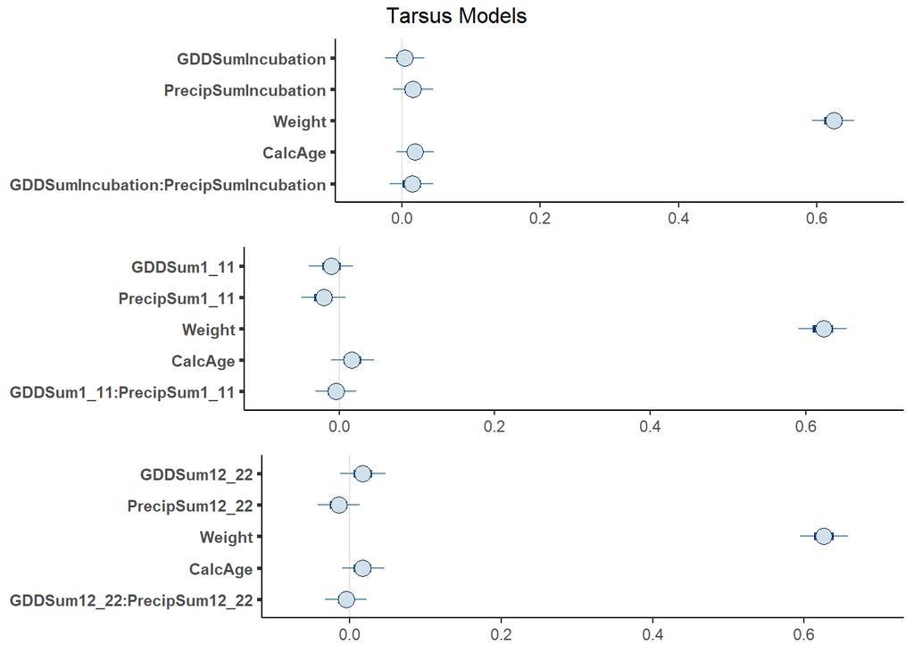

```r
TarsusModelPlots.wrap <-ggarrange(TarsusGDDIncub.plot,TarsusGDDTime1.plot,TarsusGDDTime2.plot, ncol = 1)
annotate_figure(TarsusModelPlots.wrap, top = "Tarsus Models")
```